# Fixing up our range plots

## Range Recap

Last week we made a plot of ranges through time for the canid fossil record

```r
library(ggplot2)
setwd("/Users/michael_alfaro/Dropbox/teaching/EEB 177:234 2016/range-plotting/") #you will need to change this to match your directory!
canids <- read.csv("/Users/michael_alfaro/Dropbox/teaching/EEB 177:234 2016/range-plotting/canid_fa_la.csv", header = F, as.is = T)
names(canids) <- c("genus", "species", "minage", "maxage")
head(canids)
```

```
##       genus                 species minage maxage
## 1 Aelurodon Aelurodon_asthenostylus  15.97  20.43
## 2 Aelurodon         Aelurodon_ferox  13.60  23.03
## 3 Aelurodon       Aelurodon_mcgrewi  15.97  23.03
## 4 Aelurodon   Aelurodon_montanensis  15.97  15.97
## 5 Aelurodon      Aelurodon_stirtoni  13.60  23.03
## 6 Aelurodon      Aelurodon_taxoides  10.30  23.03
```

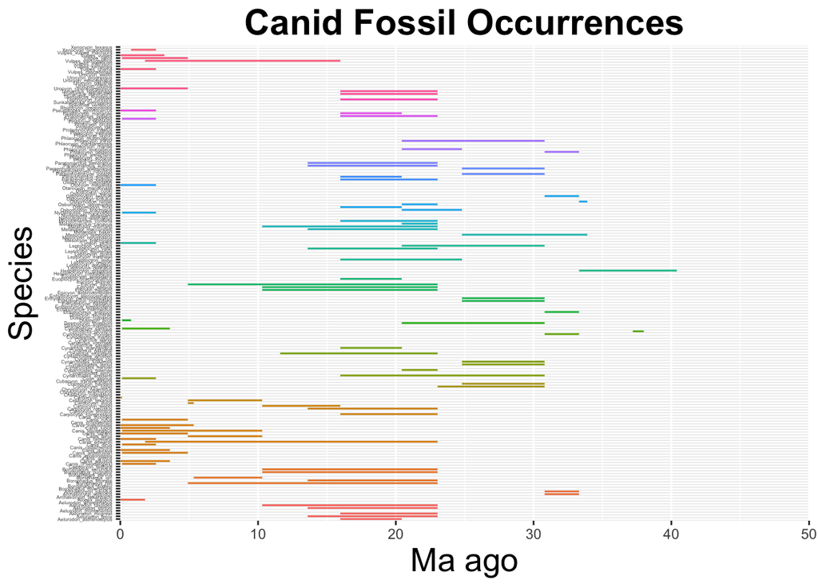

```r
canid_occ <- ggplot(canids, aes( x = species, maxage, colour = genus))
# everything
canid_occ + geom_linerange(aes(ymin = minage, ymax = maxage)) + theme(legend.position="none") +  coord_flip() +  theme(axis.text.y = element_text(size=3)) + scale_y_continuous(limits=c(0, 50), expand = c(0, 0), breaks=c(0, 10, 20, 30, 40, 50)) + labs(title = "Canid Fossil Occurrences", x = "Species", y = "Ma ago") + theme(plot.title = element_text(hjust = 0.5, size=22, face = "bold"), axis.title =element_text(size=20))
```

One problem with this plot is that the point occurrences do not show up well. Lets stretch them just a little bit so we can see them better by setting maxage to be the original max age + 500,00 years

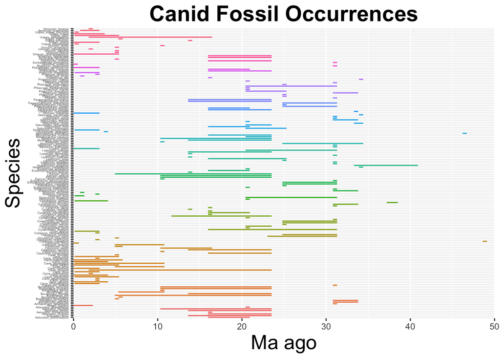

```r
canid_occ <- ggplot(canids, aes( x = species, maxage, colour = genus))
# everything
canid_occ + geom_linerange(aes(ymin = minage, ymax = maxage + 0.5)) + theme(legend.position="none") +  coord_flip() +  theme(axis.text.y = element_text(size=3)) + scale_y_continuous(limits=c(0, 50), expand = c(0, 0), breaks=c(0, 10, 20, 30, 40, 50)) + labs(title = "Canid Fossil Occurrences", x = "Species", y = "Ma ago") + theme(plot.title = element_text(hjust = 0.5, size=22, face = "bold"), axis.title =element_text(size=20))
```

A second problem is that the age ranges are not sorted in any way. The output we saw from paleotree on Tuesday was much nicer. Lets try to fix this. We are going to use an R package called forcats ([for categorical variables,](https://blog.rstudio.org/2016/08/31/forcats-0-1-0/)) to reorder the species by their minimum age. This will force ggplot to arrange the ranges so that the youngest are on top and the oldest are on the bottom.

```r
library(forcats)
```

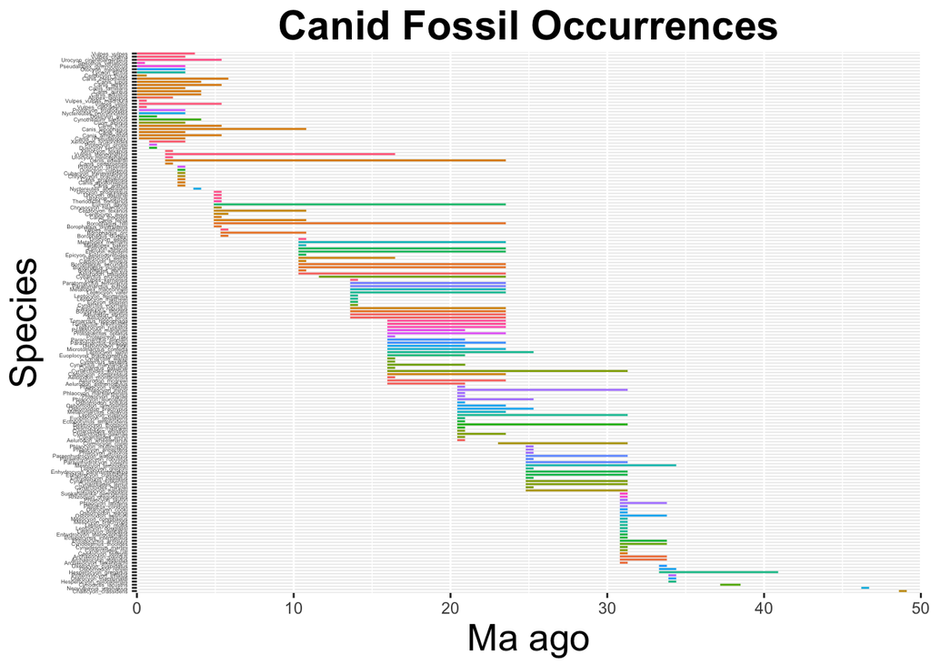

```r
canid_occ <- ggplot(canids, aes( x = fct_reorder(species, minage, .desc = T), maxage, colour = genus))

canid_occ + geom_linerange(aes(ymin = minage, ymax = maxage + 0.5)) + theme(legend.position="none") +  coord_flip() +  theme(axis.text.y = element_text(size=3)) + scale_y_continuous(limits=c(0, 50), expand = c(0, 0), breaks=c(0, 10, 20, 30, 40, 50)) + labs(title = "Canid Fossil Occurrences", x = "Species", y = "Ma ago") + theme(plot.title = element_text(hjust = 0.5, size=22, face = "bold"), axis.title =element_text(size=20))
```

This looks even better than the paleotree output because we can see the species names and we can control the labels and titles.